# Risk Factor Analysis

## Outcome Variable

**Outcome Variable:** wasted

## Predictor Variables

**Intervention Variable:** meducyrs

**Adjustment Set:**

- arm
- W_mage
- feducyrs
- hhwealth_quart
- W_mhtcm
- W_mwtkg
- W_mbmi
- W_gagebrth
- W_birthwt
- W_birthlen
- single
- W_nrooms
- impsan
- delta_W_mage
- delta_feducyrs
- delta_hhwealth_quart
- delta_W_mhtcm
- delta_W_mwtkg
- delta_W_mbmi
- delta_W_gagebrth
- delta_W_birthwt
- delta_W_birthlen
- delta_single
- delta_W_nrooms
- delta_impsan

## Stratifying Variables

The analysis was stratified on these variable(s):

- agecat
- studyid
- country

## Data Summary

| agecat | studyid | country | meducyrs | wasted | n_cell | n |
| --- | --- | --- | --- | --- | --- | --- |
| Birth | CMC-V-BCS-2002 | INDIA | High | 0 | 44 | 86 |
| Birth | CMC-V-BCS-2002 | INDIA | High | 1 | 5 | 86 |
| Birth | CMC-V-BCS-2002 | INDIA | Low | 0 | 13 | 86 |
| Birth | CMC-V-BCS-2002 | INDIA | Low | 1 | 2 | 86 |
| Birth | CMC-V-BCS-2002 | INDIA | Medium | 0 | 18 | 86 |
| Birth | CMC-V-BCS-2002 | INDIA | Medium | 1 | 4 | 86 |
| Birth | COHORTS | GUATEMALA | High | 0 | 124 | 748 |
| Birth | COHORTS | GUATEMALA | High | 1 | 33 | 748 |
| Birth | COHORTS | GUATEMALA | Low | 0 | 258 | 748 |
| Birth | COHORTS | GUATEMALA | Low | 1 | 86 | 748 |
| Birth | COHORTS | GUATEMALA | Medium | 0 | 177 | 748 |
| Birth | COHORTS | GUATEMALA | Medium | 1 | 70 | 748 |
| Birth | COHORTS | INDIA | High | 0 | 558 | 4879 |
| Birth | COHORTS | INDIA | High | 1 | 98 | 4879 |
| Birth | COHORTS | INDIA | Low | 0 | 1297 | 4879 |
| Birth | COHORTS | INDIA | Low | 1 | 305 | 4879 |
| Birth | COHORTS | INDIA | Medium | 0 | 2170 | 4879 |
| Birth | COHORTS | INDIA | Medium | 1 | 451 | 4879 |
| Birth | COHORTS | PHILIPPINES | High | 0 | 929 | 2899 |
| Birth | COHORTS | PHILIPPINES | High | 1 | 199 | 2899 |
| Birth | COHORTS | PHILIPPINES | Low | 0 | 727 | 2899 |
| Birth | COHORTS | PHILIPPINES | Low | 1 | 111 | 2899 |
| Birth | COHORTS | PHILIPPINES | Medium | 0 | 792 | 2899 |
| Birth | COHORTS | PHILIPPINES | Medium | 1 | 141 | 2899 |
| Birth | EE | PAKISTAN | High | 0 | 5 | 177 |
| Birth | EE | PAKISTAN | High | 1 | 0 | 177 |
| Birth | EE | PAKISTAN | Low | 0 | 136 | 177 |
| Birth | EE | PAKISTAN | Low | 1 | 20 | 177 |
| Birth | EE | PAKISTAN | Medium | 0 | 14 | 177 |
| Birth | EE | PAKISTAN | Medium | 1 | 2 | 177 |

[output cut: 396 more lines]

The following strata were considered:

- agecat: 24 months, studyid: CMC-V-BCS-2002, country: INDIA
- agecat: 24 months, studyid: COHORTS, country: GUATEMALA
- agecat: 24 months, studyid: COHORTS, country: INDIA
- agecat: 24 months, studyid: COHORTS, country: PHILIPPINES
- agecat: 24 months, studyid: EE, country: PAKISTAN
- agecat: 24 months, studyid: GMS-Nepal, country: NEPAL
- agecat: 24 months, studyid: IRC, country: INDIA
- agecat: 24 months, studyid: JiVitA-3, country: BANGLADESH
- agecat: 24 months, studyid: JiVitA-4, country: BANGLADESH
- agecat: 24 months, studyid: LCNI-5, country: MALAWI
- agecat: 24 months, studyid: MAL-ED, country: BANGLADESH
- agecat: 24 months, studyid: MAL-ED, country: BRAZIL
- agecat: 24 months, studyid: MAL-ED, country: INDIA
- agecat: 24 months, studyid: MAL-ED, country: NEPAL
- agecat: 24 months, studyid: MAL-ED, country: PERU
- agecat: 24 months, studyid: MAL-ED, country: SOUTH AFRICA
- agecat: 24 months, studyid: MAL-ED, country: TANZANIA, UNITED REPUBLIC OF
- agecat: 24 months, studyid: NIH-Birth, country: BANGLADESH
- agecat: 24 months, studyid: NIH-Crypto, country: BANGLADESH
- agecat: 24 months, studyid: PROBIT, country: BELARUS
- agecat: 24 months, studyid: PROVIDE, country: BANGLADESH
- agecat: 24 months, studyid: TanzaniaChild2, country: TANZANIA, UNITED REPUBLIC OF
- agecat: 24 months, studyid: ZVITAMBO, country: ZIMBABWE
- agecat: 6 months, studyid: CMC-V-BCS-2002, country: INDIA
- agecat: 6 months, studyid: COHORTS, country: GUATEMALA
- agecat: 6 months, studyid: COHORTS, country: INDIA
- agecat: 6 months, studyid: COHORTS, country: PHILIPPINES
- agecat: 6 months, studyid: EE, country: PAKISTAN
- agecat: 6 months, studyid: GMS-Nepal, country: NEPAL
- agecat: 6 months, studyid: Guatemala BSC, country: GUATEMALA
- agecat: 6 months, studyid: IRC, country: INDIA
- agecat: 6 months, studyid: JiVitA-3, country: BANGLADESH
- agecat: 6 months, studyid: JiVitA-4, country: BANGLADESH
- agecat: 6 months, studyid: LCNI-5, country: MALAWI
- agecat: 6 months, studyid: MAL-ED, country: BANGLADESH
- agecat: 6 months, studyid: MAL-ED, country: BRAZIL
- agecat: 6 months, studyid: MAL-ED, country: INDIA
- agecat: 6 months, studyid: MAL-ED, country: NEPAL
- agecat: 6 months, studyid: MAL-ED, country: PERU
- agecat: 6 months, studyid: MAL-ED, country: SOUTH AFRICA
- agecat: 6 months, studyid: MAL-ED, country: TANZANIA, UNITED REPUBLIC OF
- agecat: 6 months, studyid: NIH-Birth, country: BANGLADESH
- agecat: 6 months, studyid: NIH-Crypto, country: BANGLADESH
- agecat: 6 months, studyid: PROBIT, country: BELARUS
- agecat: 6 months, studyid: PROVIDE, country: BANGLADESH
- agecat: 6 months, studyid: SAS-CompFeed, country: INDIA
- agecat: 6 months, studyid: SAS-FoodSuppl, country: INDIA
- agecat: 6 months, studyid: TanzaniaChild2, country: TANZANIA, UNITED REPUBLIC OF
- agecat: 6 months, studyid: ZVITAMBO, country: ZIMBABWE
- agecat: Birth, studyid: CMC-V-BCS-2002, country: INDIA
- agecat: Birth, studyid: COHORTS, country: GUATEMALA
- agecat: Birth, studyid: COHORTS, country: INDIA
- agecat: Birth, studyid: COHORTS, country: PHILIPPINES
- agecat: Birth, studyid: EE, country: PAKISTAN
- agecat: Birth, studyid: GMS-Nepal, country: NEPAL
- agecat: Birth, studyid: IRC, country: INDIA
- agecat: Birth, studyid: JiVitA-3, country: BANGLADESH
- agecat: Birth, studyid: JiVitA-4, country: BANGLADESH
- agecat: Birth, studyid: MAL-ED, country: BANGLADESH
- agecat: Birth, studyid: MAL-ED, country: BRAZIL
- agecat: Birth, studyid: MAL-ED, country: INDIA
- agecat: Birth, studyid: MAL-ED, country: NEPAL
- agecat: Birth, studyid: MAL-ED, country: PERU
- agecat: Birth, studyid: MAL-ED, country: SOUTH AFRICA
- agecat: Birth, studyid: MAL-ED, country: TANZANIA, UNITED REPUBLIC OF
- agecat: Birth, studyid: NIH-Birth, country: BANGLADESH
- agecat: Birth, studyid: NIH-Crypto, country: BANGLADESH
- agecat: Birth, studyid: PROBIT, country: BELARUS
- agecat: Birth, studyid: PROVIDE, country: BANGLADESH
- agecat: Birth, studyid: SAS-CompFeed, country: INDIA
- agecat: Birth, studyid: ZVITAMBO, country: ZIMBABWE

### Dropped Strata

Some strata were dropped due to rare outcomes:

- agecat: Birth, studyid: CMC-V-BCS-2002, country: INDIA
- agecat: Birth, studyid: EE, country: PAKISTAN
- agecat: Birth, studyid: MAL-ED, country: BRAZIL
- agecat: Birth, studyid: MAL-ED, country: INDIA
- agecat: Birth, studyid: MAL-ED, country: NEPAL
- agecat: Birth, studyid: MAL-ED, country: PERU
- agecat: Birth, studyid: MAL-ED, country: SOUTH AFRICA
- agecat: Birth, studyid: MAL-ED, country: TANZANIA, UNITED REPUBLIC OF
- agecat: 6 months, studyid: EE, country: PAKISTAN
- agecat: 6 months, studyid: GMS-Nepal, country: NEPAL
- agecat: 6 months, studyid: Guatemala BSC, country: GUATEMALA
- agecat: 6 months, studyid: LCNI-5, country: MALAWI
- agecat: 6 months, studyid: MAL-ED, country: BANGLADESH
- agecat: 6 months, studyid: MAL-ED, country: BRAZIL
- agecat: 6 months, studyid: MAL-ED, country: NEPAL
- agecat: 6 months, studyid: MAL-ED, country: PERU
- agecat: 6 months, studyid: MAL-ED, country: SOUTH AFRICA
- agecat: 6 months, studyid: MAL-ED, country: TANZANIA, UNITED REPUBLIC OF
- agecat: 6 months, studyid: NIH-Crypto, country: BANGLADESH
- agecat: 6 months, studyid: SAS-FoodSuppl, country: INDIA
- agecat: 6 months, studyid: TanzaniaChild2, country: TANZANIA, UNITED REPUBLIC OF
- agecat: 24 months, studyid: EE, country: PAKISTAN
- agecat: 24 months, studyid: LCNI-5, country: MALAWI
- agecat: 24 months, studyid: MAL-ED, country: BANGLADESH
- agecat: 24 months, studyid: MAL-ED, country: BRAZIL
- agecat: 24 months, studyid: MAL-ED, country: INDIA
- agecat: 24 months, studyid: MAL-ED, country: NEPAL
- agecat: 24 months, studyid: MAL-ED, country: PERU
- agecat: 24 months, studyid: MAL-ED, country: SOUTH AFRICA
- agecat: 24 months, studyid: MAL-ED, country: TANZANIA, UNITED REPUBLIC OF
- agecat: 24 months, studyid: PROBIT, country: BELARUS
- agecat: 24 months, studyid: TanzaniaChild2, country: TANZANIA, UNITED REPUBLIC OF

## Methods Detail

We’re interested in the causal parameters $E[Y_a]$ for all values of $a \in \mathcal{A}$. These parameters represent the mean outcome if, possibly contrary to fact, we intervened to set all units to have $A=a$. Under the randomization and positivity assumptions, these are identified by the statistical parameters $\psi_a=E_W[E_{Y|A,W}(Y|A=a,W)]$. In addition, we’re interested in the mean of $Y$, $E[Y]$ under no intervention (the observed mean). We will estimate these parameters by using SuperLearner to fit the relevant likelihood factors – $E_{Y|A,W}(Y|A=a,W)$ and $p(A=a|W)$, and then updating our likelihood fit using a joint TMLE.

For unadjusted analyses ($W=\{\}$), initial likelihoods were estimated using Lrnr_glm to estimate the simple $E(Y|A)$ and Lrnr_mean to estimate $p(A)$. For adjusted analyses, a small library containing Lrnr_glmnet, Lrnr_xgboost, and Lrnr_mean was used.

Having estimated these parameters, we will then use the delta method to estimate relative risks and attributable risks relative to a prespecified baseline level of $A$.

# Results Detail

## Results Plots

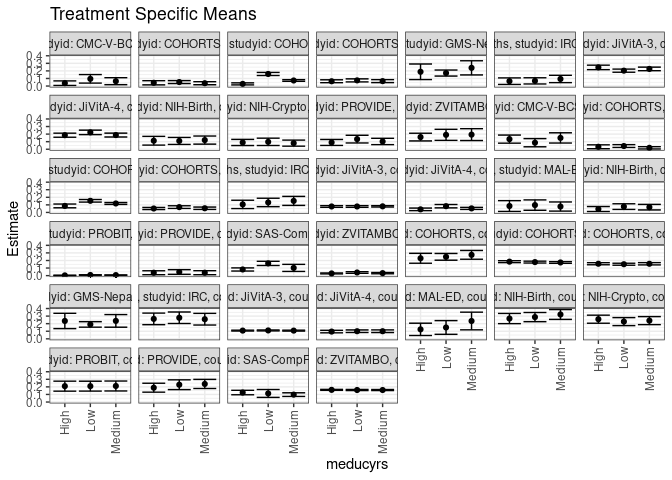

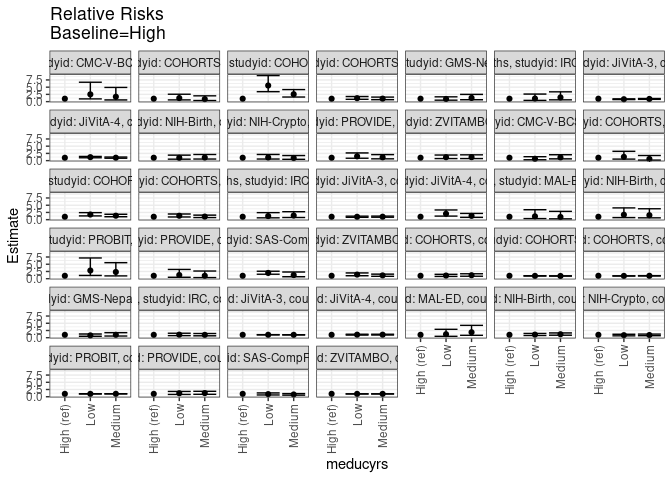

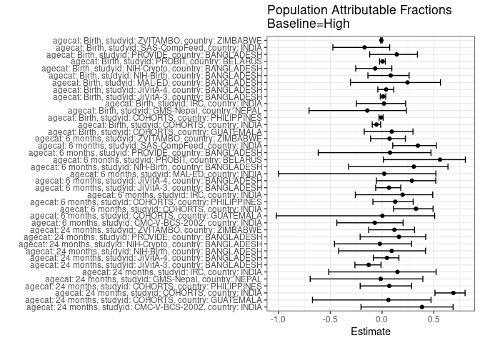

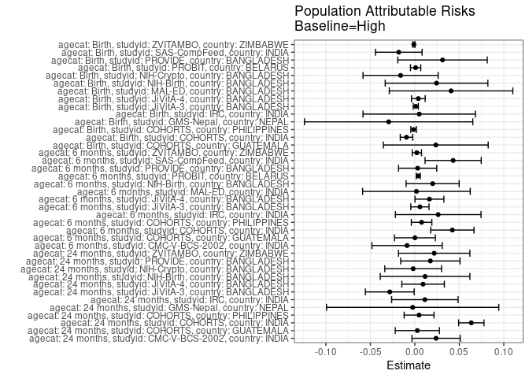

## Results Table

### Parameter: TSM

| agecat | studyid | country | intervention_level | baseline_level | estimate | ci_lower | ci_upper |
| --- | --- | --- | --- | --- | --- | --- | --- |
| Birth | COHORTS | GUATEMALA | High | NA | 0.2291027 | 0.1639115 | 0.2942939 |
| Birth | COHORTS | GUATEMALA | Low | NA | 0.2481443 | 0.2036335 | 0.2926551 |
| Birth | COHORTS | GUATEMALA | Medium | NA | 0.2744032 | 0.2164188 | 0.3323875 |
| Birth | COHORTS | INDIA | High | NA | 0.1844476 | 0.1714957 | 0.1973996 |
| Birth | COHORTS | INDIA | Low | NA | 0.1788359 | 0.1664022 | 0.1912696 |
| Birth | COHORTS | INDIA | Medium | NA | 0.1737576 | 0.1629161 | 0.1845991 |
| Birth | COHORTS | PHILIPPINES | High | NA | 0.1569826 | 0.1434889 | 0.1704763 |
| Birth | COHORTS | PHILIPPINES | Low | NA | 0.1507725 | 0.1375957 | 0.1639492 |
| Birth | COHORTS | PHILIPPINES | Medium | NA | 0.1566289 | 0.1415651 | 0.1716926 |
| Birth | GMS-Nepal | NEPAL | High | NA | 0.2360378 | 0.1349734 | 0.3371022 |
| Birth | GMS-Nepal | NEPAL | Low | NA | 0.1901594 | 0.1536744 | 0.2266444 |
| Birth | GMS-Nepal | NEPAL | Medium | NA | 0.2368673 | 0.1535308 | 0.3202037 |
| Birth | IRC | INDIA | High | NA | 0.2633147 | 0.1868982 | 0.3397313 |
| Birth | IRC | INDIA | Low | NA | 0.2781028 | 0.2020784 | 0.3541272 |
| Birth | IRC | INDIA | Medium | NA | 0.2589581 | 0.1819794 | 0.3359368 |
| Birth | JiVitA-3 | BANGLADESH | High | NA | 0.1086144 | 0.1028787 | 0.1143502 |
| Birth | JiVitA-3 | BANGLADESH | Low | NA | 0.1106790 | 0.1047865 | 0.1165716 |
| Birth | JiVitA-3 | BANGLADESH | Medium | NA | 0.1083617 | 0.1025150 | 0.1142084 |
| Birth | JiVitA-4 | BANGLADESH | High | NA | 0.0956205 | 0.0789234 | 0.1123176 |
| Birth | JiVitA-4 | BANGLADESH | Low | NA | 0.1004504 | 0.0835596 | 0.1173413 |
| Birth | JiVitA-4 | BANGLADESH | Medium | NA | 0.1004371 | 0.0831323 | 0.1177419 |
| Birth | MAL-ED | BANGLADESH | High | NA | 0.1250000 | 0.0437429 | 0.2062571 |
| Birth | MAL-ED | BANGLADESH | Low | NA | 0.1500000 | 0.0593909 | 0.2406091 |
| Birth | MAL-ED | BANGLADESH | Medium | NA | 0.2352941 | 0.1185432 | 0.3520450 |
| Birth | NIH-Birth | BANGLADESH | High | NA | 0.2677748 | 0.2004635 | 0.3350861 |
| Birth | NIH-Birth | BANGLADESH | Low | NA | 0.2870389 | 0.2265659 | 0.3475119 |
| Birth | NIH-Birth | BANGLADESH | Medium | NA | 0.3215592 | 0.2564376 | 0.3866809 |
| Birth | NIH-Crypto | BANGLADESH | High | NA | 0.2593222 | 0.2061206 | 0.3125238 |
| Birth | NIH-Crypto | BANGLADESH | Low | NA | 0.2275033 | 0.1746627 | 0.2803439 |
| Birth | NIH-Crypto | BANGLADESH | Medium | NA | 0.2404709 | 0.1876409 | 0.2933009 |

[output cut: 87 more lines]

### Parameter: E(Y)

| agecat | studyid | country | intervention_level | baseline_level | estimate | ci_lower | ci_upper |
| --- | --- | --- | --- | --- | --- | --- | --- |
| Birth | COHORTS | GUATEMALA | NA | NA | 0.2526738 | 0.2215120 | 0.2838356 |
| Birth | COHORTS | INDIA | NA | NA | 0.1750359 | 0.1643722 | 0.1856996 |
| Birth | COHORTS | PHILIPPINES | NA | NA | 0.1555709 | 0.1423748 | 0.1687670 |
| Birth | GMS-Nepal | NEPAL | NA | NA | 0.2065728 | 0.1751584 | 0.2379871 |
| Birth | IRC | INDIA | NA | NA | 0.2682216 | 0.2212677 | 0.3151755 |
| Birth | JiVitA-3 | BANGLADESH | NA | NA | 0.1096842 | 0.1045577 | 0.1148108 |
| Birth | JiVitA-4 | BANGLADESH | NA | NA | 0.0995399 | 0.0841638 | 0.1149160 |
| Birth | MAL-ED | BANGLADESH | NA | NA | 0.1657143 | 0.1104670 | 0.2209616 |
| Birth | NIH-Birth | BANGLADESH | NA | NA | 0.2921739 | 0.2549711 | 0.3293768 |
| Birth | NIH-Crypto | BANGLADESH | NA | NA | 0.2432815 | 0.2116319 | 0.2749310 |
| Birth | PROBIT | BELARUS | NA | NA | 0.2103206 | 0.1450833 | 0.2755580 |
| Birth | PROVIDE | BANGLADESH | NA | NA | 0.2199248 | 0.1846953 | 0.2551543 |
| Birth | SAS-CompFeed | INDIA | NA | NA | 0.1069810 | 0.0760961 | 0.1378659 |
| Birth | ZVITAMBO | ZIMBABWE | NA | NA | 0.1594945 | 0.1531752 | 0.1658137 |
| 6 months | CMC-V-BCS-2002 | INDIA | NA | NA | 0.1250000 | 0.0911644 | 0.1588356 |
| 6 months | COHORTS | GUATEMALA | NA | NA | 0.0325289 | 0.0212599 | 0.0437978 |
| 6 months | COHORTS | INDIA | NA | NA | 0.1283521 | 0.1194359 | 0.1372684 |
| 6 months | COHORTS | PHILIPPINES | NA | NA | 0.0594974 | 0.0505830 | 0.0684118 |
| 6 months | IRC | INDIA | NA | NA | 0.1323529 | 0.0994307 | 0.1652752 |
| 6 months | JiVitA-3 | BANGLADESH | NA | NA | 0.0846305 | 0.0798233 | 0.0894378 |
| 6 months | JiVitA-4 | BANGLADESH | NA | NA | 0.0570539 | 0.0482012 | 0.0659066 |
| 6 months | MAL-ED | INDIA | NA | NA | 0.0865385 | 0.0482372 | 0.1248397 |
| 6 months | NIH-Birth | BANGLADESH | NA | NA | 0.0651769 | 0.0442802 | 0.0860736 |
| 6 months | PROBIT | BELARUS | NA | NA | 0.0068541 | 0.0051915 | 0.0085167 |
| 6 months | PROVIDE | BANGLADESH | NA | NA | 0.0414594 | 0.0255348 | 0.0573839 |
| 6 months | SAS-CompFeed | INDIA | NA | NA | 0.1244378 | 0.0992652 | 0.1496104 |
| 6 months | ZVITAMBO | ZIMBABWE | NA | NA | 0.0312058 | 0.0275075 | 0.0349041 |
| 24 months | CMC-V-BCS-2002 | INDIA | NA | NA | 0.0618280 | 0.0373207 | 0.0863352 |
| 24 months | COHORTS | GUATEMALA | NA | NA | 0.0458801 | 0.0333262 | 0.0584341 |
| 24 months | COHORTS | INDIA | NA | NA | 0.0921747 | 0.0833896 | 0.1009599 |
| 24 months | COHORTS | PHILIPPINES | NA | NA | 0.0681911 | 0.0582056 | 0.0781766 |
| 24 months | GMS-Nepal | NEPAL | NA | NA | 0.1859504 | 0.1512529 | 0.2206479 |
| 24 months | IRC | INDIA | NA | NA | 0.0757946 | 0.0501131 | 0.1014762 |
| 24 months | JiVitA-3 | BANGLADESH | NA | NA | 0.2181099 | 0.2082292 | 0.2279905 |
| 24 months | JiVitA-4 | BANGLADESH | NA | NA | 0.1947502 | 0.1814990 | 0.2080014 |
| 24 months | NIH-Birth | BANGLADESH | NA | NA | 0.1238318 | 0.0925894 | 0.1550741 |
| 24 months | NIH-Crypto | BANGLADESH | NA | NA | 0.0875486 | 0.0630907 | 0.1120065 |
| 24 months | PROVIDE | BANGLADESH | NA | NA | 0.1070812 | 0.0818727 | 0.1322897 |
| 24 months | ZVITAMBO | ZIMBABWE | NA | NA | 0.1824480 | 0.1460286 | 0.2188675 |

### Parameter: RR

| agecat | studyid | country | intervention_level | baseline_level | estimate | ci_lower | ci_upper |
| --- | --- | --- | --- | --- | --- | --- | --- |
| Birth | COHORTS | GUATEMALA | High | High | 1.0000000 | 1.0000000 | 1.0000000 |
| Birth | COHORTS | GUATEMALA | Low | High | 1.0831138 | 0.7774090 | 1.5090326 |
| Birth | COHORTS | GUATEMALA | Medium | High | 1.1977300 | 0.8420282 | 1.7036924 |
| Birth | COHORTS | INDIA | High | High | 1.0000000 | 1.0000000 | 1.0000000 |
| Birth | COHORTS | INDIA | Low | High | 0.9695753 | 0.9160386 | 1.0262410 |
| Birth | COHORTS | INDIA | Medium | High | 0.9420429 | 0.9006646 | 0.9853223 |
| Birth | COHORTS | PHILIPPINES | High | High | 1.0000000 | 1.0000000 | 1.0000000 |
| Birth | COHORTS | PHILIPPINES | Low | High | 0.9604404 | 0.9293825 | 0.9925361 |
| Birth | COHORTS | PHILIPPINES | Medium | High | 0.9977465 | 0.9437631 | 1.0548177 |
| Birth | GMS-Nepal | NEPAL | High | High | 1.0000000 | 1.0000000 | 1.0000000 |
| Birth | GMS-Nepal | NEPAL | Low | High | 0.8056313 | 0.5038427 | 1.2881834 |
| Birth | GMS-Nepal | NEPAL | Medium | High | 1.0035142 | 0.5766507 | 1.7463620 |
| Birth | IRC | INDIA | High | High | 1.0000000 | 1.0000000 | 1.0000000 |
| Birth | IRC | INDIA | Low | High | 1.0561612 | 0.7203002 | 1.5486272 |
| Birth | IRC | INDIA | Medium | High | 0.9834546 | 0.6631724 | 1.4584186 |
| Birth | JiVitA-3 | BANGLADESH | High | High | 1.0000000 | 1.0000000 | 1.0000000 |
| Birth | JiVitA-3 | BANGLADESH | Low | High | 1.0190082 | 0.9784721 | 1.0612236 |
| Birth | JiVitA-3 | BANGLADESH | Medium | High | 0.9976728 | 0.9585150 | 1.0384303 |
| Birth | JiVitA-4 | BANGLADESH | High | High | 1.0000000 | 1.0000000 | 1.0000000 |
| Birth | JiVitA-4 | BANGLADESH | Low | High | 1.0505114 | 0.9191877 | 1.2005972 |
| Birth | JiVitA-4 | BANGLADESH | Medium | High | 1.0503722 | 0.9215946 | 1.1971444 |
| Birth | MAL-ED | BANGLADESH | High | High | 1.0000000 | 1.0000000 | 1.0000000 |
| Birth | MAL-ED | BANGLADESH | Low | High | 1.2000000 | 0.4940740 | 2.9145433 |
| Birth | MAL-ED | BANGLADESH | Medium | High | 1.8823529 | 0.8308823 | 4.2644459 |
| Birth | NIH-Birth | BANGLADESH | High | High | 1.0000000 | 1.0000000 | 1.0000000 |
| Birth | NIH-Birth | BANGLADESH | Low | High | 1.0719413 | 0.7735330 | 1.4854675 |
| Birth | NIH-Birth | BANGLADESH | Medium | High | 1.2008568 | 0.8706413 | 1.6563159 |
| Birth | NIH-Crypto | BANGLADESH | High | High | 1.0000000 | 1.0000000 | 1.0000000 |
| Birth | NIH-Crypto | BANGLADESH | Low | High | 0.8773000 | 0.6473932 | 1.1888529 |
| Birth | NIH-Crypto | BANGLADESH | Medium | High | 0.9273056 | 0.6913835 | 1.2437320 |

[output cut: 87 more lines]

### Parameter: PAR

| agecat | studyid | country | intervention_level | baseline_level | estimate | ci_lower | ci_upper |
| --- | --- | --- | --- | --- | --- | --- | --- |
| Birth | COHORTS | GUATEMALA | High | NA | 0.0235711 | -0.0353262 | 0.0824684 |
| Birth | COHORTS | INDIA | High | NA | -0.0094118 | -0.0164223 | -0.0024012 |
| Birth | COHORTS | PHILIPPINES | High | NA | -0.0014117 | -0.0045340 | 0.0017105 |
| Birth | GMS-Nepal | NEPAL | High | NA | -0.0294650 | -0.1241260 | 0.0651960 |
| Birth | IRC | INDIA | High | NA | 0.0049068 | -0.0582865 | 0.0681002 |
| Birth | JiVitA-3 | BANGLADESH | High | NA | 0.0010698 | -0.0018057 | 0.0039453 |
| Birth | JiVitA-4 | BANGLADESH | High | NA | 0.0039194 | -0.0037897 | 0.0116286 |
| Birth | MAL-ED | BANGLADESH | High | NA | 0.0407143 | -0.0287520 | 0.1101806 |
| Birth | NIH-Birth | BANGLADESH | High | NA | 0.0243991 | -0.0333293 | 0.0821275 |
| Birth | NIH-Crypto | BANGLADESH | High | NA | -0.0160407 | -0.0582737 | 0.0261923 |
| Birth | PROBIT | BELARUS | High | NA | 0.0008808 | -0.0048918 | 0.0066534 |
| Birth | PROVIDE | BANGLADESH | High | NA | 0.0311330 | -0.0191845 | 0.0814505 |
| Birth | SAS-CompFeed | INDIA | High | NA | -0.0180880 | -0.0443282 | 0.0081522 |
| Birth | ZVITAMBO | ZIMBABWE | High | NA | -0.0010479 | -0.0022253 | 0.0001294 |
| 6 months | CMC-V-BCS-2002 | INDIA | High | NA | -0.0087580 | -0.0482800 | 0.0307641 |
| 6 months | COHORTS | GUATEMALA | High | NA | 0.0000964 | -0.0228389 | 0.0230318 |
| 6 months | COHORTS | INDIA | High | NA | 0.0421662 | 0.0178185 | 0.0665140 |
| 6 months | COHORTS | PHILIPPINES | High | NA | 0.0075815 | -0.0039482 | 0.0191111 |
| 6 months | IRC | INDIA | High | NA | 0.0262623 | -0.0219023 | 0.0744268 |
| 6 months | JiVitA-3 | BANGLADESH | High | NA | 0.0056803 | -0.0045346 | 0.0158951 |
| 6 months | JiVitA-4 | BANGLADESH | High | NA | 0.0164038 | 0.0001602 | 0.0326474 |
| 6 months | MAL-ED | INDIA | High | NA | 0.0017927 | -0.0587275 | 0.0623129 |
| 6 months | NIH-Birth | BANGLADESH | High | NA | 0.0200156 | -0.0098052 | 0.0498364 |
| 6 months | PROBIT | BELARUS | High | NA | 0.0038432 | 0.0016285 | 0.0060579 |
| 6 months | PROVIDE | BANGLADESH | High | NA | 0.0031819 | -0.0183012 | 0.0246649 |
| 6 months | SAS-CompFeed | INDIA | High | NA | 0.0430669 | 0.0114824 | 0.0746514 |
| 6 months | ZVITAMBO | ZIMBABWE | High | NA | 0.0022510 | -0.0029763 | 0.0074783 |
| 24 months | CMC-V-BCS-2002 | INDIA | High | NA | 0.0238533 | -0.0032516 | 0.0509582 |
| 24 months | COHORTS | GUATEMALA | High | NA | 0.0028179 | -0.0220618 | 0.0276977 |
| 24 months | COHORTS | INDIA | High | NA | 0.0635090 | 0.0492627 | 0.0777554 |
| 24 months | COHORTS | PHILIPPINES | High | NA | 0.0047567 | -0.0120349 | 0.0215483 |
| 24 months | GMS-Nepal | NEPAL | High | NA | -0.0024590 | -0.0993408 | 0.0944229 |
| 24 months | IRC | INDIA | High | NA | 0.0112785 | -0.0261027 | 0.0486597 |
| 24 months | JiVitA-3 | BANGLADESH | High | NA | -0.0281814 | -0.0556241 | -0.0007387 |
| 24 months | JiVitA-4 | BANGLADESH | High | NA | 0.0092589 | -0.0146669 | 0.0331847 |
| 24 months | NIH-Birth | BANGLADESH | High | NA | 0.0115006 | -0.0388937 | 0.0618950 |
| 24 months | NIH-Crypto | BANGLADESH | High | NA | -0.0018790 | -0.0337918 | 0.0300339 |
| 24 months | PROVIDE | BANGLADESH | High | NA | 0.0174424 | -0.0159203 | 0.0508052 |
| 24 months | ZVITAMBO | ZIMBABWE | High | NA | 0.0217806 | -0.0183317 | 0.0618929 |

### Parameter: PAF

| agecat | studyid | country | intervention_level | baseline_level | estimate | ci_lower | ci_upper |
| --- | --- | --- | --- | --- | --- | --- | --- |
| Birth | COHORTS | GUATEMALA | High | NA | 0.0932867 | -0.1721094 | 0.2985902 |
| Birth | COHORTS | INDIA | High | NA | -0.0537705 | -0.0946215 | -0.0144441 |
| Birth | COHORTS | PHILIPPINES | High | NA | -0.0090746 | -0.0293775 | 0.0108278 |
| Birth | GMS-Nepal | NEPAL | High | NA | -0.1426374 | -0.7057067 | 0.2345576 |
| Birth | IRC | INDIA | High | NA | 0.0182940 | -0.2477641 | 0.2276210 |
| Birth | JiVitA-3 | BANGLADESH | High | NA | 0.0097533 | -0.0167909 | 0.0356046 |
| Birth | JiVitA-4 | BANGLADESH | High | NA | 0.0393756 | -0.0410635 | 0.1135995 |
| Birth | MAL-ED | BANGLADESH | High | NA | 0.2456897 | -0.3051245 | 0.5640385 |
| Birth | NIH-Birth | BANGLADESH | High | NA | 0.0835087 | -0.1367725 | 0.2611044 |
| Birth | NIH-Crypto | BANGLADESH | High | NA | -0.0659347 | -0.2545470 | 0.0943210 |
| Birth | PROBIT | BELARUS | High | NA | 0.0041878 | -0.0237792 | 0.0313909 |
| Birth | PROVIDE | BANGLADESH | High | NA | 0.1415620 | -0.1196777 | 0.3418500 |
| Birth | SAS-CompFeed | INDIA | High | NA | -0.1690771 | -0.4753887 | 0.0736400 |
| Birth | ZVITAMBO | ZIMBABWE | High | NA | -0.0065704 | -0.0139821 | 0.0007871 |
| 6 months | CMC-V-BCS-2002 | INDIA | High | NA | -0.0700637 | -0.4373815 | 0.2033873 |
| 6 months | COHORTS | GUATEMALA | High | NA | 0.0029643 | -1.0222350 | 0.5084250 |
| 6 months | COHORTS | INDIA | High | NA | 0.3285200 | 0.1111110 | 0.4927540 |
| 6 months | COHORTS | PHILIPPINES | High | NA | 0.1274252 | -0.0883182 | 0.3004006 |
| 6 months | IRC | INDIA | High | NA | 0.1984261 | -0.2581490 | 0.4893126 |
| 6 months | JiVitA-3 | BANGLADESH | High | NA | 0.0671183 | -0.0616700 | 0.1802837 |
| 6 months | JiVitA-4 | BANGLADESH | High | NA | 0.2875144 | -0.0551101 | 0.5188789 |
| 6 months | MAL-ED | INDIA | High | NA | 0.0207156 | -1.0000169 | 0.5205051 |
| 6 months | NIH-Birth | BANGLADESH | High | NA | 0.3070968 | -0.3224587 | 0.6369528 |
| 6 months | PROBIT | BELARUS | High | NA | 0.5607131 | 0.0129124 | 0.8045027 |
| 6 months | PROVIDE | BANGLADESH | High | NA | 0.0767464 | -0.6169746 | 0.4728444 |
| 6 months | SAS-CompFeed | INDIA | High | NA | 0.3460916 | 0.1032165 | 0.5231890 |
| 6 months | ZVITAMBO | ZIMBABWE | High | NA | 0.0721340 | -0.1109366 | 0.2250365 |
| 24 months | CMC-V-BCS-2002 | INDIA | High | NA | 0.3858008 | -0.2035002 | 0.6865471 |
| 24 months | COHORTS | GUATEMALA | High | NA | 0.0614198 | -0.6721728 | 0.4731808 |
| 24 months | COHORTS | INDIA | High | NA | 0.6890069 | 0.5111415 | 0.8021580 |
| 24 months | COHORTS | PHILIPPINES | High | NA | 0.0697556 | -0.2115411 | 0.2857407 |
| 24 months | GMS-Nepal | NEPAL | High | NA | -0.0132239 | -0.6944573 | 0.3941290 |
| 24 months | IRC | INDIA | High | NA | 0.1488033 | -0.5154091 | 0.5218877 |
| 24 months | JiVitA-3 | BANGLADESH | High | NA | -0.1292074 | -0.2623516 | -0.0101064 |
| 24 months | JiVitA-4 | BANGLADESH | High | NA | 0.0475425 | -0.0834130 | 0.1626691 |
| 24 months | NIH-Birth | BANGLADESH | High | NA | 0.0928732 | -0.4193640 | 0.4202480 |
| 24 months | NIH-Crypto | BANGLADESH | High | NA | -0.0214618 | -0.4594834 | 0.2851004 |
| 24 months | PROVIDE | BANGLADESH | High | NA | 0.1628900 | -0.2117730 | 0.4217125 |
| 24 months | ZVITAMBO | ZIMBABWE | High | NA | 0.1193796 | -0.1285163 | 0.3128214 |